# Módulo 5 - Técnicas de Programação II | Python

## Projeto Final - História das Olimpíadas

Este projeto consiste em uma análise de dados históricos dos jogos olímpicos.

Utilize qualquer uma das bibliotecas estudadas (`matplotlib`, `seaborn` e `plotly`) para realizar as atividades propostas. Não há problema em usar apenas uma para realizar todas as atividades, nem em utilizar cada uma delas em uma atividade diferente - siga suas preferências pessoais!

Utilize os (muitos) parâmetros permitidos por cada função e/ou atributos dos objetos fornecidos pelas bibliotecas para criar uma identidade visual coesa para ser utilizada em todo o projeto. Use títulos, legendas e rótulos nos eixos para deixar os gráficos verdadeiramente informativos. E não se esqueça que a simples escolha das cores a serem utilizadas pode tornar os gráficos ainda mais interessantes!

## Metadados:

O arquivo `athlete_events.csv` contém 271116 linhas e 15 colunas. Cada linha corresponde a um indivíduo (atleta) que competiu em um evento olímpico individual. Veja a descrição das 15 colunas, a seguir:

- **ID:** Valor único para cada atleta
- **Name:** Nome do atleta
- **Sex:** Gênero do atleta (M para masculino e F para feminino)
- **Age:** Idade do atleta no momento da competição
- **Height:** Altura do atleta, em centímetros
- **Weight:** Peso do atleta, em kg
- **Team:** Nome do time
- **NOC:** National Olympic Committee (código de 3 letras)
- **Games:** Ano e temporada dos jogos
- **Year:** Ano dos jogos
- **Season:** Temporada dos jogos (summer para verão e winter para inverno)
- **City:** Cidade em que ocorreu os jogos
- **Sport:** Esporte praticado pelo atleta
- **Event:** Categoria/modalidade da competição
- **Medal:** Medalha adquirida: Gold (ouro), Silver (prata), Bronze ou NA

```python
import pandas as pd
import numpy as np
import plotly.express as px
import matplotlib.pyplot as plt
import seaborn as sns
```

```python
df = pd.read_csv('./data/athlete_events.csv', sep = ',')


df.shape[0]
```

```
271116
```

## O Brasil nas olímpiadas

**1.** Crie um DataFrame contendo apenas informações sobre atletas **brasileiros**. Exiba a quantidade de linhas desse novo DataFrame.

```python
df_brasil = df[df['NOC']== 'BRA'].copy()
print(f' A quantidade de linhas no dataframe é {df_brasil.shape[0]}')
```

```
 A quantidade de linhas no dataframe é 3848
```

**2. Será que existe alguma correlação entre a altura do atleta e seu desempenho, para algum esporte? Faça essa análise separadamente para cada gênero, e conclua.**

Gere um ou mais gráficos de sua escolha, em que seja possível comparar as alturas dos atletas de cada esporte, separando-os por gênero. Se necessário, crie colunas ou DataFrames auxiliares.

**Facilitador:** se quiser, analise apenas os esportes em que se tenha ao menos 5 atletas medalhistas e 5 atletas não medalhistas, para facilitar visualizações e conclusões.

**3. Vamos analisar agora as medalhas que nossos atletas trouxeram para casa.**

Crie uma visualização de sua preferência para mostrar, por esporte, a proporção de medalhas de ouro, prata e bronze que nosso país já consquistou.

**Facilitador:** Se preferir, mostre as proporções apenas para os 6 esportes que tiveram mais medalhas.

*DICA:* Cuidado! Esportes em equipe dão medalhas a todos os jogadores, mas só contabilizam uma vez!

```python
sem_repetição_de_medalhas = df_brasil.groupby(by=['Medal','Sport','Year','Event'], as_index = False).count()
sem_repetição_de_medalhas.Medal = sem_repetição_de_medalhas.Medal.replace('Sem Medalhas',np.nan)
```

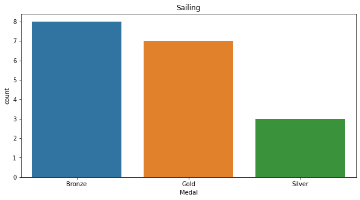

```python
plt.figure(figsize=(10,5))
y= sem_repetição_de_medalhas[sem_repetição_de_medalhas.Sport == 'Sailing'].copy()
sns.countplot(x=y.Medal)
plt.title('Sailing')


plt.show()
```

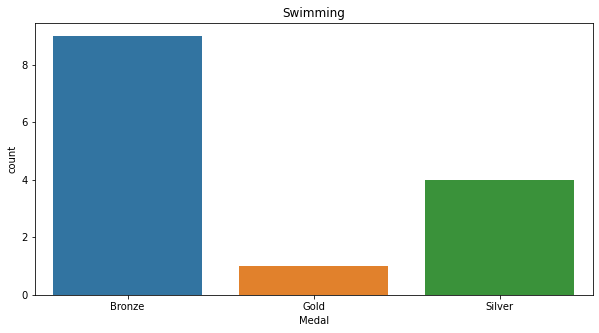

```python
plt.figure(figsize=(10,5))
y= sem_repetição_de_medalhas[sem_repetição_de_medalhas.Sport == 'Swimming'].copy()
sns.countplot(x=y.Medal)
plt.title('Swimming')

plt.show()
```

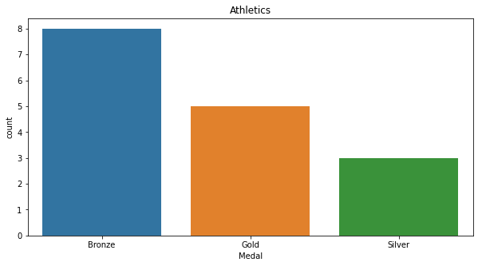

```python
plt.figure(figsize=(10,5))
y= sem_repetição_de_medalhas[sem_repetição_de_medalhas.Sport == 'Athletics'].copy()
sns.countplot(x=y.Medal)
plt.title('Athletics')

plt.show()
```

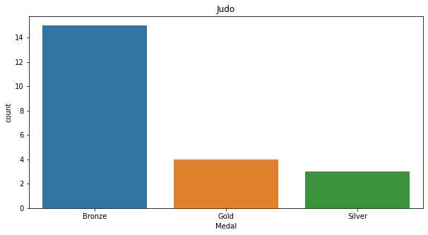

```python
plt.figure(figsize=(10,5))
y= sem_repetição_de_medalhas[sem_repetição_de_medalhas.Sport == 'Judo'].copy()
sns.countplot(x=y.Medal)
plt.title('Judo')

plt.show()
```

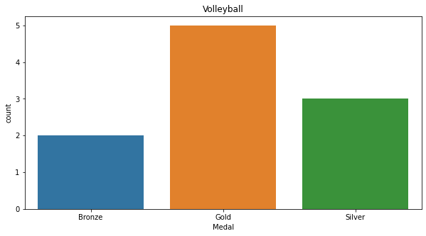

```python
plt.figure(figsize=(10,5))
y= sem_repetição_de_medalhas[sem_repetição_de_medalhas.Sport == 'Volleyball'].copy()
sns.countplot(x=y.Medal)
plt.title('Volleyball')

plt.show()
```

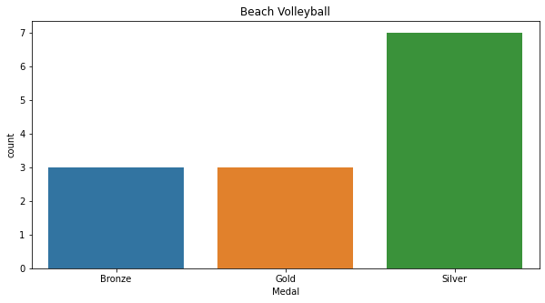

```python
plt.figure(figsize=(10,5))
y= sem_repetição_de_medalhas[sem_repetição_de_medalhas.Sport == 'Beach Volleyball'].copy()
sns.countplot(x=y.Medal)
plt.title('Beach Volleyball')

plt.show()
```

**4. Para finalizar a história do Brasil, vamos ver a série temporal de medalhas brasileiras.**

Crie um gráfico de sua escolha, que mostre o total de medalhas de ouro, prata e bronze, por edição da olimpíada (em ordem cronológica).

*DICA:* Mais uma vez, tome cuidado com os esportes em grupo - os contabilize apenas uma vez!

**5. Agora é com vocês!**

Escolha uma análise visual que julga interessante de fazer neste conjunto de dados, faça o(s) gráficos(s) necessários e comente os resultados.